# Univariate Descriptive Statistics

### Lab 2: Austin Animal Shelter Data

Have you ever been curious about how long it takes for an animal to be adopted? To investigate questions like this, we contacted the Austin Animal Shelter and they provided us with information about 473 cats and dogs. Included in the dataset are information about how the animals arrived at the shelter, their sex, breed, age, weight, and the number of days spent in the shelter. The data is contained in AnimalData.csv and each variable is described in the codebook file.

### Pre-Lab Section

**Primary Research Question**

How many days do animals spend in the shelter before they are adopted?

```r
#Loading the datasets through SDSFoundations package
library(SDSFoundations)
animaldata <- AnimalData
#Following command gives the documentation of AnimalData dataset
?AnimalData
```

1a. How many variables are in this dataset?  
Answer: 24

```r
ncol(animaldata)
```

```
[1] 24
```

1b. How many of the first 10 animals in the dataset were adopted?  
Answer:4

```r
nrow(animaldata[1:10,][animaldata[1:10,]$Outcome.Type =='Adoption',])
```

```
[1] 4
```

1c. Was the first owner-surrendered animal in the dataset neutered? Answer: No

```r
owner_surrender[1,]$Neutered.Status
```

```
[1] Intact
Levels: Intact Neutered Spayed
```

2a. What variable tells us the length of time an animal stayed in the shelter? Ans: Days.Shelter

2b. What type of variable is Days.Shelter? Ans: numerical/integer

```r
class(animaldata$Days.Shelter)
```

```
[1] "integer"
```

2c. What variable tells us if the animal was adopted? Ans: Outcome.Type

2d. What type of variable is Outcome.Type? Ans: categorical/factor

```r
levels(animaldata$Outcome.Type)
```

```
[1] "Adoption"          "Died"              "Humane Euthanasia"
[4] "Return to Owner"   "Transfer"
```

**Prepare and Conduct the analysis section:**

How many days do animals spend in the shelter before they are adopted?

```r
#Find the number of animals that were adopted
table(animaldata$Outcome.Type)
```

```
         Adoption              Died Humane Euthanasia   Return to Owner
              204                 3                39                73
         Transfer
              154
```

```r
#Pull out only adopted animals
adopted <- animaldata[animaldata$Outcome.Type=="Adoption",]
#Pull out just the days in shelter for the adopted animals
daystoadopt <- adopted$Days.Shelter
```

1.How would you describe the shape of the distribution of daystoadopt?  
Answer: Positively Skewed

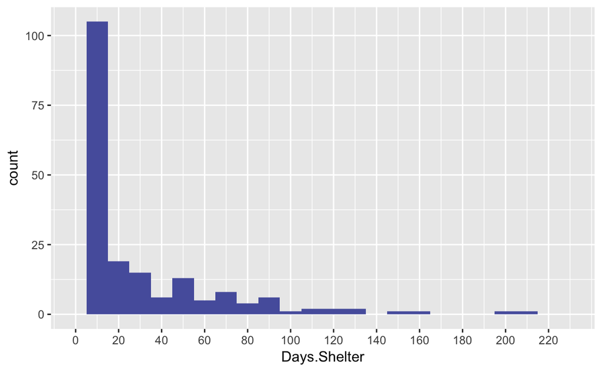

2. Which measures of center and spread should you report for this data?  
   Answer: Median and IQR
3. Numericals values for the following: Center:13 Spread:30

```r
fivenum(daystoadopt)
```

```
[1]   2   8  13  38 211
```

It looks like one adopted animal spent much more time in the shelter than the others.

4a. How many days was this animal in the shelter?  
Answer:211

```r
daystoadopt[which.max(daystoadopt)]
```

```
[1] 211
```

4b. What was the z-score for this particular animal? Round to the nearest TWO decimal places.  
Answer:5.09

```r
(211-mean(daystoadopt))/sd(daystoadopt)
```

```
[1] 5.08842
```

5. Why should we NOT report a z-score for this animal, even though we can calculate one?  
   Answer:Distribution is skewed

### Lab Section

Austin Animal Shelter Data

Have you ever been curious about how long it takes for an animal to be adopted? To investigate questions like this, we contacted the Austin Animal Shelter and they provided us with information about 473 cats and dogs. Included in the dataset are information about how the animals arrived at the shelter, their sex, breed, age, weight, and the number of days spent in the shelter. The data is contained in AnimalData.csv and each variable is described in the codebook file.

**Primary Research Question**

Compare the weight of adult cats and dogs at the shelter. How typical would it be to find a 13-pound cat? What about a 13-pound dog?

**Reflect and Analyse the Question**

1a. How many adult dogs are in the shelter?  
Answer: 226

```r
table(Adult$Animal.Type)
```

```
Cat Dog
 56 226
```

1b. How many adult cats are in the shelter?  
Answer:56

2a. What is the shape of the distribution of weight for adult dogs? Answer: Positively skewed

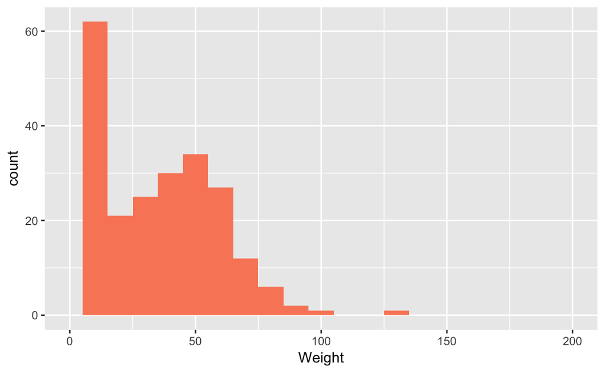

2b. What is the shape of the distribution of weight for adult cats? Answer: Approximately Normal

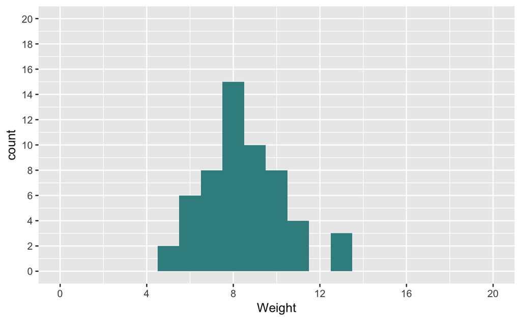

3a. Which measure of center should be used to describe the average weight of the adult cats?  
Answer: Mean

3b. Average adult cat weight in pounds (rounded to one decimal place)  
Answer: 8.6

```r
mean(AdultCats$Weight)
```

```
[1] 8.603571
```

4. What is the standard deviation for the weight of the adult cats? Round to two decimal places.  
   Answer: 1.91

```r
sd(AdultCats$Weight)
```

```
[1] 1.911517
```

5. What is the z-score of a 13 pound adult cat? Round to one decimal point.  
   Answer: 2.3

```r
(13-mean(AdultCats$Weight))/sd(AdultCats$Weight)
```

```
[1] 2.299969
```

6. Which of these best describes the location of a 13 pound adult cat in the shelter distribution?  
   Answer: More than 2 standard deviations above the mean.
7. What proportion of adult cats weigh more than 13 pounds, according to your data? Use the following code to answer this question: Round to three decimal places.  
   Answer: 0.011

```r
1-pnorm(2.29)
```

```
[1] 0.01101066
```

8a. What quartile would contain a 13-pound adult dog?  
Answer: First

8b. What percentage of adult dogs in the shelter weigh more than 13 pounds?  
Answer: Approximately 75%

### Problem Set Section

1a. What was the most common way that dogs arrived in the shelter? (as defined by the “Intake.Type” variable)  
Answer: Stray

```r
table(animaldata$Intake.Type)
```

```
Euthanasia Request    Owner Surrender      Public Assist              Stray
                 1                129                 23                320
```

1b. What proportion of dogs were brought to the shelter as an owner surrender? (Round to 3 decimal places.)  
Answer:0.278

```r
nrow(owner_surrender_dogs)/nrow(Dogs)
```

```
[1] 0.2783505
```

1c. Of the dogs that were brought to the shelter as an owner surrender, how many were returned to their owner?  
Answer: 2

```r
table(owner_surrender_dogs$Outcome.Type)
```

```
         Adoption              Died Humane Euthanasia   Return to Owner
               33                 0                13                 2
         Transfer
               33
```

1d. What was the mean number of days that the dogs referenced in Question 1c spent at the shelter before being returned to their owner? (Round to 1 decimal place.)  
Answer:3.5

```r
mean(owner_surrender_dogs$Days.Shelter[owner_surrender_dogs$Outcome.Type=='Return to Owner'])
```

```
[1] 3.5
```